# Intro to Pandas

Many of us work with large and complicated datasets. The Pandas library is a useful tool for data analysis in Python. In this lesson,we will introduce some tools that can be used to analyze a population data set from Gapminder http://www.gapminder.org/.

## Objectives

- Read tabular data into an IPython notebook
- Access columns of the data
- Isolate subsets of the data
- Generate plots based on subsetted data

## Resources

- http://pandas.pydata.org/pandas-docs/stable/index.html
- http://pandas.pydata.org/pandas-docs/stable/basics.html
- http://pandas.pydata.org/pandas-docs/dev/generated/pandas.DataFrame.html
- https://github.com/datacarpentry/datacarpentry/blob/master/cheatsheets/R_pandas_compare.md
- http://pandas.pydata.org/pandas-docs/stable/visualization.html

## Preparing for the lesson

From you desktop navigiate to WiSE-swc/pandas

## Working with tabular data

### Question

What is tabular data? Who works with tabular data?

Some data is stored in a tabular format, meaning the data is organized into rows and columns.

- We will use a libarary called pandas to read this dataset into our notebook.
- Pandas should be installed with the Anaconda distribution.
- Documentation: http://pandas.pydata.org/pandas-docs/stable/index.html

```python
import pandas as pd
import numpy as np
import matplotlib.pyplot as plt
```

To read the Gapminder text file we will use a pandas funtion called read_table().

```python
gDat = pd.read_table('gapminderDataFiveYear.txt')
```

## Familiarizing yourself with the data

It is often useful get familiar with data we are working with. What is recorded in our dataset? How is it organized? We can gain some insight by taking a quick peak at the dataset.

```python
gDat
```

|  | country | year | pop | continent | lifeExp | gdpPercap |
| --- | --- | --- | --- | --- | --- | --- |
| 0 | Afghanistan | 1952 | 8425333 | Asia | 28.801 | 779.445314 |
| 1 | Afghanistan | 1957 | 9240934 | Asia | 30.332 | 820.853030 |
| 2 | Afghanistan | 1962 | 10267083 | Asia | 31.997 | 853.100710 |
| 3 | Afghanistan | 1967 | 11537966 | Asia | 34.020 | 836.197138 |
| 4 | Afghanistan | 1972 | 13079460 | Asia | 36.088 | 739.981106 |
| 5 | Afghanistan | 1977 | 14880372 | Asia | 38.438 | 786.113360 |
| 6 | Afghanistan | 1982 | 12881816 | Asia | 39.854 | 978.011439 |
| 7 | Afghanistan | 1987 | 13867957 | Asia | 40.822 | 852.395945 |
| 8 | Afghanistan | 1992 | 16317921 | Asia | 41.674 | 649.341395 |
| 9 | Afghanistan | 1997 | 22227415 | Asia | 41.763 | 635.341351 |
| 10 | Afghanistan | 2002 | 25268405 | Asia | 42.129 | 726.734055 |
| 11 | Afghanistan | 2007 | 31889923 | Asia | 43.828 | 974.580338 |
| 12 | Albania | 1952 | 1282697 | Europe | 55.230 | 1601.056136 |
| 13 | Albania | 1957 | 1476505 | Europe | 59.280 | 1942.284244 |
| 14 | Albania | 1962 | 1728137 | Europe | 64.820 | 2312.888958 |
| 15 | Albania | 1967 | 1984060 | Europe | 66.220 | 2760.196931 |
| 16 | Albania | 1972 | 2263554 | Europe | 67.690 | 3313.422188 |
| 17 | Albania | 1977 | 2509048 | Europe | 68.930 | 3533.003910 |
| 18 | Albania | 1982 | 2780097 | Europe | 70.420 | 3630.880722 |
| 19 | Albania | 1987 | 3075321 | Europe | 72.000 | 3738.932735 |
| 20 | Albania | 1992 | 3326498 | Europe | 71.581 | 2497.437901 |
| 21 | Albania | 1997 | 3428038 | Europe | 72.950 | 3193.054604 |
| 22 | Albania | 2002 | 3508512 | Europe | 75.651 | 4604.211737 |
| 23 | Albania | 2007 | 3600523 | Europe | 76.423 | 5937.029526 |
| 24 | Algeria | 1952 | 9279525 | Africa | 43.077 | 2449.008185 |
| 25 | Algeria | 1957 | 10270856 | Africa | 45.685 | 3013.976023 |
| 26 | Algeria | 1962 | 11000948 | Africa | 48.303 | 2550.816880 |
| 27 | Algeria | 1967 | 12760499 | Africa | 51.407 | 3246.991771 |
| 28 | Algeria | 1972 | 14760787 | Africa | 54.518 | 4182.663766 |
| 29 | Algeria | 1977 | 17152804 | Africa | 58.014 | 4910.416756 |
| ... | ... | ... | ... | ... | ... | ... |
| 1674 | Yemen, Rep. | 1982 | 9657618 | Asia | 49.113 | 1977.557010 |
| 1675 | Yemen, Rep. | 1987 | 11219340 | Asia | 52.922 | 1971.741538 |
| 1676 | Yemen, Rep. | 1992 | 13367997 | Asia | 55.599 | 1879.496673 |
| 1677 | Yemen, Rep. | 1997 | 15826497 | Asia | 58.020 | 2117.484526 |
| 1678 | Yemen, Rep. | 2002 | 18701257 | Asia | 60.308 | 2234.820827 |
| 1679 | Yemen, Rep. | 2007 | 22211743 | Asia | 62.698 | 2280.769906 |
| 1680 | Zambia | 1952 | 2672000 | Africa | 42.038 | 1147.388831 |
| 1681 | Zambia | 1957 | 3016000 | Africa | 44.077 | 1311.956766 |
| 1682 | Zambia | 1962 | 3421000 | Africa | 46.023 | 1452.725766 |
| 1683 | Zambia | 1967 | 3900000 | Africa | 47.768 | 1777.077318 |
| 1684 | Zambia | 1972 | 4506497 | Africa | 50.107 | 1773.498265 |
| 1685 | Zambia | 1977 | 5216550 | Africa | 51.386 | 1588.688299 |
| 1686 | Zambia | 1982 | 6100407 | Africa | 51.821 | 1408.678565 |
| 1687 | Zambia | 1987 | 7272406 | Africa | 50.821 | 1213.315116 |
| 1688 | Zambia | 1992 | 8381163 | Africa | 46.100 | 1210.884633 |
| 1689 | Zambia | 1997 | 9417789 | Africa | 40.238 | 1071.353818 |
| 1690 | Zambia | 2002 | 10595811 | Africa | 39.193 | 1071.613938 |
| 1691 | Zambia | 2007 | 11746035 | Africa | 42.384 | 1271.211593 |
| 1692 | Zimbabwe | 1952 | 3080907 | Africa | 48.451 | 406.884115 |
| 1693 | Zimbabwe | 1957 | 3646340 | Africa | 50.469 | 518.764268 |
| 1694 | Zimbabwe | 1962 | 4277736 | Africa | 52.358 | 527.272182 |
| 1695 | Zimbabwe | 1967 | 4995432 | Africa | 53.995 | 569.795071 |
| 1696 | Zimbabwe | 1972 | 5861135 | Africa | 55.635 | 799.362176 |
| 1697 | Zimbabwe | 1977 | 6642107 | Africa | 57.674 | 685.587682 |
| 1698 | Zimbabwe | 1982 | 7636524 | Africa | 60.363 | 788.855041 |
| 1699 | Zimbabwe | 1987 | 9216418 | Africa | 62.351 | 706.157306 |
| 1700 | Zimbabwe | 1992 | 10704340 | Africa | 60.377 | 693.420786 |
| 1701 | Zimbabwe | 1997 | 11404948 | Africa | 46.809 | 792.449960 |
| 1702 | Zimbabwe | 2002 | 11926563 | Africa | 39.989 | 672.038623 |
| 1703 | Zimbabwe | 2007 | 12311143 | Africa | 43.487 | 469.709298 |

1704 rows × 6 columns

In each row, there is a recording for a country, year, population, continent, life expectancy, and GDP per capita. Further, each row has an interger label.

Since the data set is large, it would be nice to read the column headings without printing the entire dataset. First, we need to know more about how Python treats this data set. What type of object are we working with?

```python
type(gDat)
```

```
pandas.core.frame.DataFrame
```

Pandas loads this tabular data as a DataFrame object. This is a special type of object that is particularly useful for organizing data. Some more information can be found at the documentation webpage.

- http://pandas.pydata.org/pandas-docs/dev/generated/pandas.DataFrame.html

DataFrame objects have a number of attributes.

```python
gDat.shape
```

```
(1704, 6)
```

```python
gDat.columns
```

```
Index([u'country', u'year', u'pop', u'continent', u'lifeExp', u'gdpPercap'], dtype='object')
```

DataFrame objects also a number of methods.

Look at the first few lines.

```python
gDat.head()
```

|  | country | year | pop | continent | lifeExp | gdpPercap |
| --- | --- | --- | --- | --- | --- | --- |
| 0 | Afghanistan | 1952 | 8425333 | Asia | 28.801 | 779.445314 |
| 1 | Afghanistan | 1957 | 9240934 | Asia | 30.332 | 820.853030 |
| 2 | Afghanistan | 1962 | 10267083 | Asia | 31.997 | 853.100710 |
| 3 | Afghanistan | 1967 | 11537966 | Asia | 34.020 | 836.197138 |
| 4 | Afghanistan | 1972 | 13079460 | Asia | 36.088 | 739.981106 |

Pass an integer into head() to specify the number of lines to print

```python
gDat.head(7)
```

|  | country | year | pop | continent | lifeExp | gdpPercap |
| --- | --- | --- | --- | --- | --- | --- |
| 0 | Afghanistan | 1952 | 8425333 | Asia | 28.801 | 779.445314 |
| 1 | Afghanistan | 1957 | 9240934 | Asia | 30.332 | 820.853030 |
| 2 | Afghanistan | 1962 | 10267083 | Asia | 31.997 | 853.100710 |
| 3 | Afghanistan | 1967 | 11537966 | Asia | 34.020 | 836.197138 |
| 4 | Afghanistan | 1972 | 13079460 | Asia | 36.088 | 739.981106 |
| 5 | Afghanistan | 1977 | 14880372 | Asia | 38.438 | 786.113360 |
| 6 | Afghanistan | 1982 | 12881816 | Asia | 39.854 | 978.011439 |

Look at the end

```python
gDat.tail()
```

|  | country | year | pop | continent | lifeExp | gdpPercap |
| --- | --- | --- | --- | --- | --- | --- |
| 1699 | Zimbabwe | 1987 | 9216418 | Africa | 62.351 | 706.157306 |
| 1700 | Zimbabwe | 1992 | 10704340 | Africa | 60.377 | 693.420786 |
| 1701 | Zimbabwe | 1997 | 11404948 | Africa | 46.809 | 792.449960 |
| 1702 | Zimbabwe | 2002 | 11926563 | Africa | 39.989 | 672.038623 |
| 1703 | Zimbabwe | 2007 | 12311143 | Africa | 43.487 | 469.709298 |

Summary statistics with describe() * Count, mean,std, min, quartiles, max * Note: maybe not useful for every column

```python
gDat.describe()
```

|  | year | pop | lifeExp | gdpPercap |
| --- | --- | --- | --- | --- |
| count | 1704.00000 | 1.704000e+03 | 1704.000000 | 1704.000000 |
| mean | 1979.50000 | 2.960121e+07 | 59.474439 | 7215.327081 |
| std | 17.26533 | 1.061579e+08 | 12.917107 | 9857.454543 |
| min | 1952.00000 | 6.001100e+04 | 23.599000 | 241.165877 |
| 25% | 1965.75000 | 2.793664e+06 | 48.198000 | 1202.060309 |
| 50% | 1979.50000 | 7.023596e+06 | 60.712500 | 3531.846989 |
| 75% | 1993.25000 | 1.958522e+07 | 70.845500 | 9325.462346 |
| max | 2007.00000 | 1.318683e+09 | 82.603000 | 113523.132900 |

More resources: http://pandas.pydata.org/pandas-docs/stable/basics.html

## A closer look at the data

It would be useful to look at sections of the data, rather than the entire dataset all at once. We might also want to use simple plots to take a closer look at the data.

Select a row of data with ix. * select row with label 0.

```python
gDat.ix[[0]]
```

|  | country | year | pop | continent | lifeExp | gdpPercap |
| --- | --- | --- | --- | --- | --- | --- |
| 0 | Afghanistan | 1952 | 8425333 | Asia | 28.801 | 779.445314 |

- select a set of rows

```python
gDat.ix[[0,5,10]]
```

|  | country | year | pop | continent | lifeExp | gdpPercap |
| --- | --- | --- | --- | --- | --- | --- |
| 0 | Afghanistan | 1952 | 8425333 | Asia | 28.801 | 779.445314 |
| 5 | Afghanistan | 1977 | 14880372 | Asia | 38.438 | 786.113360 |
| 10 | Afghanistan | 2002 | 25268405 | Asia | 42.129 | 726.734055 |

- select a range of rows like in numpy indexing

```python
gDat[0:5]
```

|  | country | year | pop | continent | lifeExp | gdpPercap |
| --- | --- | --- | --- | --- | --- | --- |
| 0 | Afghanistan | 1952 | 8425333 | Asia | 28.801 | 779.445314 |
| 1 | Afghanistan | 1957 | 9240934 | Asia | 30.332 | 820.853030 |
| 2 | Afghanistan | 1962 | 10267083 | Asia | 31.997 | 853.100710 |
| 3 | Afghanistan | 1967 | 11537966 | Asia | 34.020 | 836.197138 |
| 4 | Afghanistan | 1972 | 13079460 | Asia | 36.088 | 739.981106 |

- extract a column

```python
gDat.lifeExp
```

```
0     28.801
1     30.332
2     31.997
3     34.020
4     36.088
5     38.438
6     39.854
7     40.822
8     41.674
9     41.763
10    42.129
11    43.828
12    55.230
13    59.280
14    64.820
```

[output cut: 17 more lines]

or use an indexing-like notation

```python
gDat['lifeExp']
```

```
0     28.801
1     30.332
2     31.997
3     34.020
4     36.088
5     38.438
6     39.854
7     40.822
8     41.674
9     41.763
10    42.129
11    43.828
12    55.230
13    59.280
14    64.820
```

[output cut: 17 more lines]

Many of operations we saw earlier can apply to single column.

```python
gDat['lifeExp'].head()
```

```
0    28.801
1    30.332
2    31.997
3    34.020
4    36.088
Name: lifeExp, dtype: float64
```

```python
gDat['lifeExp'].describe()
```

```
count    1704.000000
mean       59.474439
std        12.917107
min        23.599000
25%        48.198000
50%        60.712500
75%        70.845500
max        82.603000
dtype: float64
```

In this dataset, the year column functions a bit like categorical data since there are only a few unique values.

```python
gDat['year'].describe()
```

```
count    1704.00000
mean     1979.50000
std        17.26533
min      1952.00000
25%      1965.75000
50%      1979.50000
75%      1993.25000
max      2007.00000
dtype: float64
```

But the continent and country columns are truly categorical

```python
gDat['continent'].describe()
```

```
count       1704
unique         5
top       Africa
freq         624
dtype: object
```

```python
gDat['country'].describe()
```

```
count               1704
unique               142
top       Czech Republic
freq                  12
dtype: object
```

These categorical columns display a different set of summary statistics. Note that country, continent were not included in the gDat.describe() command.

## Some visualualization tools

Several plots can be easily generated for DataFrame objects using the plot method.

First, display the plots inline with a magic command:

```python
%matplotlib inline
```

We can specify the type of plot with the kind argument. Also, choose the independent and dependent variables with x and y arguments. * Plot year vs life expectancy in a scatter plot.

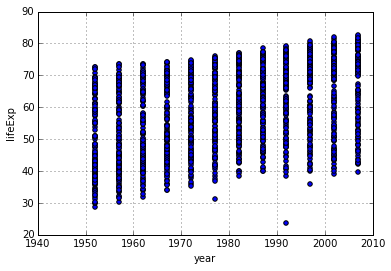

```python
gDat.plot(x='year',y='lifeExp',kind='scatter' )
```

- Plot gdp per capity vs life expectancy in a scatter plot

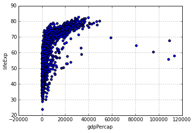

```python
gDat.plot(x='gdpPercap',y='lifeExp',kind='scatter')
```

### Question

What other kinds of plots can be generate with the plot() command?

We can also generate plots for specific columns.

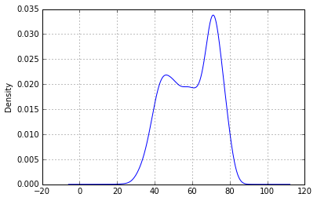

```python
gDat['lifeExp'].plot(kind='kde')
```

Histograms are also availble.

```
array([[<matplotlib.axes._subplots.AxesSubplot object at 0x0000000012DF6160>]], dtype=object)
```

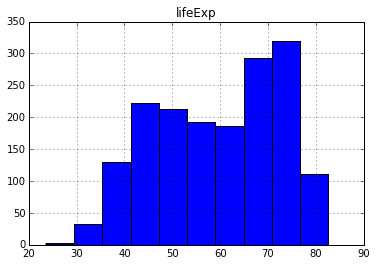

```python
gDat.hist(column='lifeExp')
```

## Subsetting and grouping

Sometimes we need to look at only parts of the data. For example, we might want to look at the data for a particular country or in a particular year. Or we may want to group the data by continent.

### Groupby

We can use the groupby method to split up the data according to repeated values in each column. For example, group the data by continent.

```python
continents=gDat.groupby('continent')
```

- list the number of unique continents.

```python
len(continents)
```

```
5
```

### Question

How many unique countries are there? Years?

- list the names of the continents and the number of data points in each.

```python
continents.size()
```

```
continent
Africa       624
Americas     300
Asia         396
Europe       360
Oceania       24
dtype: int64
```

- Plot in a barchart.

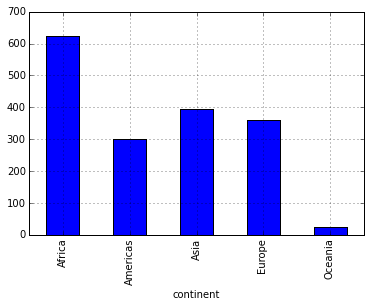

```python
continents.size().plot(kind='bar')
```

- Horizontal bar plot

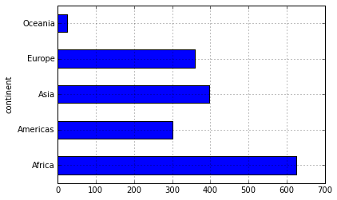

```python
continents.size().plot(kind='barh')
```

Retrieve a particular group with the get_group() command.

```python
continents.get_group('Africa').describe()
```

|  | year | pop | lifeExp | gdpPercap |
| --- | --- | --- | --- | --- |
| count | 624.00000 | 6.240000e+02 | 624.00000 | 624.000000 |
| mean | 1979.50000 | 9.916003e+06 | 48.86533 | 2193.754578 |
| std | 17.27411 | 1.549092e+07 | 9.15021 | 2827.929863 |
| min | 1952.00000 | 6.001100e+04 | 23.59900 | 241.165877 |
| 25% | 1965.75000 | 1.342075e+06 | 42.37250 | 761.247010 |
| 50% | 1979.50000 | 4.579311e+06 | 47.79200 | 1192.138217 |
| 75% | 1993.25000 | 1.080149e+07 | 54.41150 | 2377.417422 |
| max | 2007.00000 | 1.350312e+08 | 76.44200 | 21951.211760 |

### Question

What is the minimum life expectancy for Asia?

```python
continents.get_group('Asia')['lifeExp'].min()
```

```
28.800999999999998
```

```python
continents.get_group('Asia').describe()
```

|  | year | pop | lifeExp | gdpPercap |
| --- | --- | --- | --- | --- |
| count | 396.000000 | 3.960000e+02 | 396.000000 | 396.000000 |
| mean | 1979.500000 | 7.703872e+07 | 60.064903 | 7902.150428 |
| std | 17.282097 | 2.068852e+08 | 11.864532 | 14045.373112 |
| min | 1952.000000 | 1.204470e+05 | 28.801000 | 331.000000 |
| 25% | 1965.750000 | 3.844393e+06 | 51.426250 | 1056.993223 |
| 50% | 1979.500000 | 1.453083e+07 | 61.791500 | 2646.786844 |
| 75% | 1993.250000 | 4.630035e+07 | 69.505250 | 8549.255654 |
| max | 2007.000000 | 1.318683e+09 | 82.603000 | 113523.132900 |

### Subset

We can also isolate sets of data with the isin() fuction. isin() returns a list of indices where the data matches a condition. These indices can be passed into the DataFrame object as an argument. * Isolate all of the data with year 2007

```python
gDat[gDat['year'].isin([2007])]
```

|  | country | year | pop | continent | lifeExp | gdpPercap |
| --- | --- | --- | --- | --- | --- | --- |
| 11 | Afghanistan | 2007 | 31889923 | Asia | 43.828 | 974.580338 |
| 23 | Albania | 2007 | 3600523 | Europe | 76.423 | 5937.029526 |
| 35 | Algeria | 2007 | 33333216 | Africa | 72.301 | 6223.367465 |
| 47 | Angola | 2007 | 12420476 | Africa | 42.731 | 4797.231267 |
| 59 | Argentina | 2007 | 40301927 | Americas | 75.320 | 12779.379640 |
| 71 | Australia | 2007 | 20434176 | Oceania | 81.235 | 34435.367440 |
| 83 | Austria | 2007 | 8199783 | Europe | 79.829 | 36126.492700 |
| 95 | Bahrain | 2007 | 708573 | Asia | 75.635 | 29796.048340 |
| 107 | Bangladesh | 2007 | 150448339 | Asia | 64.062 | 1391.253792 |
| 119 | Belgium | 2007 | 10392226 | Europe | 79.441 | 33692.605080 |
| 131 | Benin | 2007 | 8078314 | Africa | 56.728 | 1441.284873 |
| 143 | Bolivia | 2007 | 9119152 | Americas | 65.554 | 3822.137084 |
| 155 | Bosnia and Herzegovina | 2007 | 4552198 | Europe | 74.852 | 7446.298803 |
| 167 | Botswana | 2007 | 1639131 | Africa | 50.728 | 12569.851770 |
| 179 | Brazil | 2007 | 190010647 | Americas | 72.390 | 9065.800825 |
| 191 | Bulgaria | 2007 | 7322858 | Europe | 73.005 | 10680.792820 |
| 203 | Burkina Faso | 2007 | 14326203 | Africa | 52.295 | 1217.032994 |
| 215 | Burundi | 2007 | 8390505 | Africa | 49.580 | 430.070692 |
| 227 | Cambodia | 2007 | 14131858 | Asia | 59.723 | 1713.778686 |
| 239 | Cameroon | 2007 | 17696293 | Africa | 50.430 | 2042.095240 |
| 251 | Canada | 2007 | 33390141 | Americas | 80.653 | 36319.235010 |
| 263 | Central African Republic | 2007 | 4369038 | Africa | 44.741 | 706.016537 |
| 275 | Chad | 2007 | 10238807 | Africa | 50.651 | 1704.063724 |
| 287 | Chile | 2007 | 16284741 | Americas | 78.553 | 13171.638850 |
| 299 | China | 2007 | 1318683096 | Asia | 72.961 | 4959.114854 |
| 311 | Colombia | 2007 | 44227550 | Americas | 72.889 | 7006.580419 |
| 323 | Comoros | 2007 | 710960 | Africa | 65.152 | 986.147879 |
| 335 | Congo, Dem. Rep. | 2007 | 64606759 | Africa | 46.462 | 277.551859 |
| 347 | Congo, Rep. | 2007 | 3800610 | Africa | 55.322 | 3632.557798 |
| 359 | Costa Rica | 2007 | 4133884 | Americas | 78.782 | 9645.061420 |
| ... | ... | ... | ... | ... | ... | ... |
| 1355 | Sierra Leone | 2007 | 6144562 | Africa | 42.568 | 862.540756 |
| 1367 | Singapore | 2007 | 4553009 | Asia | 79.972 | 47143.179640 |
| 1379 | Slovak Republic | 2007 | 5447502 | Europe | 74.663 | 18678.314350 |
| 1391 | Slovenia | 2007 | 2009245 | Europe | 77.926 | 25768.257590 |
| 1403 | Somalia | 2007 | 9118773 | Africa | 48.159 | 926.141068 |
| 1415 | South Africa | 2007 | 43997828 | Africa | 49.339 | 9269.657808 |
| 1427 | Spain | 2007 | 40448191 | Europe | 80.941 | 28821.063700 |
| 1439 | Sri Lanka | 2007 | 20378239 | Asia | 72.396 | 3970.095407 |
| 1451 | Sudan | 2007 | 42292929 | Africa | 58.556 | 2602.394995 |
| 1463 | Swaziland | 2007 | 1133066 | Africa | 39.613 | 4513.480643 |
| 1475 | Sweden | 2007 | 9031088 | Europe | 80.884 | 33859.748350 |
| 1487 | Switzerland | 2007 | 7554661 | Europe | 81.701 | 37506.419070 |
| 1499 | Syria | 2007 | 19314747 | Asia | 74.143 | 4184.548089 |
| 1511 | Taiwan | 2007 | 23174294 | Asia | 78.400 | 28718.276840 |
| 1523 | Tanzania | 2007 | 38139640 | Africa | 52.517 | 1107.482182 |
| 1535 | Thailand | 2007 | 65068149 | Asia | 70.616 | 7458.396327 |
| 1547 | Togo | 2007 | 5701579 | Africa | 58.420 | 882.969944 |
| 1559 | Trinidad and Tobago | 2007 | 1056608 | Americas | 69.819 | 18008.509240 |
| 1571 | Tunisia | 2007 | 10276158 | Africa | 73.923 | 7092.923025 |
| 1583 | Turkey | 2007 | 71158647 | Europe | 71.777 | 8458.276384 |
| 1595 | Uganda | 2007 | 29170398 | Africa | 51.542 | 1056.380121 |
| 1607 | United Kingdom | 2007 | 60776238 | Europe | 79.425 | 33203.261280 |
| 1619 | United States | 2007 | 301139947 | Americas | 78.242 | 42951.653090 |
| 1631 | Uruguay | 2007 | 3447496 | Americas | 76.384 | 10611.462990 |
| 1643 | Venezuela | 2007 | 26084662 | Americas | 73.747 | 11415.805690 |
| 1655 | Vietnam | 2007 | 85262356 | Asia | 74.249 | 2441.576404 |
| 1667 | West Bank and Gaza | 2007 | 4018332 | Asia | 73.422 | 3025.349798 |
| 1679 | Yemen, Rep. | 2007 | 22211743 | Asia | 62.698 | 2280.769906 |
| 1691 | Zambia | 2007 | 11746035 | Africa | 42.384 | 1271.211593 |
| 1703 | Zimbabwe | 2007 | 12311143 | Africa | 43.487 | 469.709298 |

142 rows × 6 columns

You can also use "==" instead of isin().

- Isolate a country (Uruguay).

```python
gDat[gDat['country'] =='Uruguay']
```

|  | country | year | pop | continent | lifeExp | gdpPercap |
| --- | --- | --- | --- | --- | --- | --- |
| 1620 | Uruguay | 1952 | 2252965 | Americas | 66.071 | 5716.766744 |
| 1621 | Uruguay | 1957 | 2424959 | Americas | 67.044 | 6150.772969 |
| 1622 | Uruguay | 1962 | 2598466 | Americas | 68.253 | 5603.357717 |
| 1623 | Uruguay | 1967 | 2748579 | Americas | 68.468 | 5444.619620 |
| 1624 | Uruguay | 1972 | 2829526 | Americas | 68.673 | 5703.408898 |
| 1625 | Uruguay | 1977 | 2873520 | Americas | 69.481 | 6504.339663 |
| 1626 | Uruguay | 1982 | 2953997 | Americas | 70.805 | 6920.223051 |
| 1627 | Uruguay | 1987 | 3045153 | Americas | 71.918 | 7452.398969 |
| 1628 | Uruguay | 1992 | 3149262 | Americas | 72.752 | 8137.004775 |
| 1629 | Uruguay | 1997 | 3262838 | Americas | 74.223 | 9230.240708 |
| 1630 | Uruguay | 2002 | 3363085 | Americas | 75.307 | 7727.002004 |
| 1631 | Uruguay | 2007 | 3447496 | Americas | 76.384 | 10611.462990 |

We could have also accomplished this by accessing the indices of these rows:

```python
gDat[1620:1632]
```

|  | country | year | pop | continent | lifeExp | gdpPercap |
| --- | --- | --- | --- | --- | --- | --- |
| 1620 | Uruguay | 1952 | 2252965 | Americas | 66.071 | 5716.766744 |
| 1621 | Uruguay | 1957 | 2424959 | Americas | 67.044 | 6150.772969 |
| 1622 | Uruguay | 1962 | 2598466 | Americas | 68.253 | 5603.357717 |
| 1623 | Uruguay | 1967 | 2748579 | Americas | 68.468 | 5444.619620 |
| 1624 | Uruguay | 1972 | 2829526 | Americas | 68.673 | 5703.408898 |
| 1625 | Uruguay | 1977 | 2873520 | Americas | 69.481 | 6504.339663 |
| 1626 | Uruguay | 1982 | 2953997 | Americas | 70.805 | 6920.223051 |
| 1627 | Uruguay | 1987 | 3045153 | Americas | 71.918 | 7452.398969 |
| 1628 | Uruguay | 1992 | 3149262 | Americas | 72.752 | 8137.004775 |
| 1629 | Uruguay | 1997 | 3262838 | Americas | 74.223 | 9230.240708 |
| 1630 | Uruguay | 2002 | 3363085 | Americas | 75.307 | 7727.002004 |
| 1631 | Uruguay | 2007 | 3447496 | Americas | 76.384 | 10611.462990 |

But this isn't very helpful for a few reasons 1. We need to know the rows that are associated with Urugray ahead of time. How are we supposed to find that? 2. If the DataFrame changes then we need to change the indices.

### Exercise

Write function that will take two countries as an argument and plot the life expectancy vs year for each country on the same axis.

```python
def compare_lifeExp(country1, country2):
    """Plot life expectancy vs year for country1 and country2"""

    for c in [country1,country2]:
        gDat[gDat['country']==c].plot(x='year',y='lifeExp')
    plt.legend((country1,country2))
```

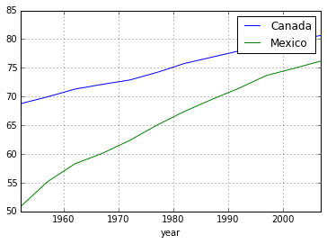

```python
compare_lifeExp('Canada','Mexico')
```

### Pivot Table

Another option for subsetting is to use a pivot table to group the data. * http://pandas.pydata.org/pandas-docs/dev/generated/pandas.tools.pivot.pivot_table.html

The pivot_table allows us to organize the information in a different way. For instance, we might prefer to think of the year column as a single set of observations and index the data in that way. For simplicity, we will view the population of each country indexed by year. We will send these arguments in the pivot_table function: * index = 'year' * columns = 'country' * values = 'pop'

```python
pd.pivot_table(gDat,index=['year'],columns='country', values='pop')
```

| country year | Afghanistan | Albania | Algeria | Angola | Argentina | Australia | Austria | Bahrain | Bangladesh | Belgium | ... | Uganda | United Kingdom | United States | Uruguay | Venezuela | Vietnam | West Bank and Gaza | Yemen, Rep. | Zambia | Zimbabwe |
| --- | --- | --- | --- | --- | --- | --- | --- | --- | --- | --- | --- | --- | --- | --- | --- | --- | --- | --- | --- | --- | --- |
| 1952 | 8425333 | 1282697 | 9279525 | 4232095 | 17876956 | 8691212 | 6927772 | 120447 | 46886859 | 8730405 | ... | 5824797 | 50430000 | 157553000 | 2252965 | 5439568 | 26246839 | 1030585 | 4963829 | 2672000 | 3080907 |
| 1957 | 9240934 | 1476505 | 10270856 | 4561361 | 19610538 | 9712569 | 6965860 | 138655 | 51365468 | 8989111 | ... | 6675501 | 51430000 | 171984000 | 2424959 | 6702668 | 28998543 | 1070439 | 5498090 | 3016000 | 3646340 |
| 1962 | 10267083 | 1728137 | 11000948 | 4826015 | 21283783 | 10794968 | 7129864 | 171863 | 56839289 | 9218400 | ... | 7688797 | 53292000 | 186538000 | 2598466 | 8143375 | 33796140 | 1133134 | 6120081 | 3421000 | 4277736 |
| 1967 | 11537966 | 1984060 | 12760499 | 5247469 | 22934225 | 11872264 | 7376998 | 202182 | 62821884 | 9556500 | ... | 8900294 | 54959000 | 198712000 | 2748579 | 9709552 | 39463910 | 1142636 | 6740785 | 3900000 | 4995432 |
| 1972 | 13079460 | 2263554 | 14760787 | 5894858 | 24779799 | 13177000 | 7544201 | 230800 | 70759295 | 9709100 | ... | 10190285 | 56079000 | 209896000 | 2829526 | 11515649 | 44655014 | 1089572 | 7407075 | 4506497 | 5861135 |
| 1977 | 14880372 | 2509048 | 17152804 | 6162675 | 26983828 | 14074100 | 7568430 | 297410 | 80428306 | 9821800 | ... | 11457758 | 56179000 | 220239000 | 2873520 | 13503563 | 50533506 | 1261091 | 8403990 | 5216550 | 6642107 |
| 1982 | 12881816 | 2780097 | 20033753 | 7016384 | 29341374 | 15184200 | 7574613 | 377967 | 93074406 | 9856303 | ... | 12939400 | 56339704 | 232187835 | 2953997 | 15620766 | 56142181 | 1425876 | 9657618 | 6100407 | 7636524 |
| 1987 | 13867957 | 3075321 | 23254956 | 7874230 | 31620918 | 16257249 | 7578903 | 454612 | 103764241 | 9870200 | ... | 15283050 | 56981620 | 242803533 | 3045153 | 17910182 | 62826491 | 1691210 | 11219340 | 7272406 | 9216418 |
| 1992 | 16317921 | 3326498 | 26298373 | 8735988 | 33958947 | 17481977 | 7914969 | 529491 | 113704579 | 10045622 | ... | 18252190 | 57866349 | 256894189 | 3149262 | 20265563 | 69940728 | 2104779 | 13367997 | 8381163 | 10704340 |
| 1997 | 22227415 | 3428038 | 29072015 | 9875024 | 36203463 | 18565243 | 8069876 | 598561 | 123315288 | 10199787 | ... | 21210254 | 58808266 | 272911760 | 3262838 | 22374398 | 76048996 | 2826046 | 15826497 | 9417789 | 11404948 |
| 2002 | 25268405 | 3508512 | 31287142 | 10866106 | 38331121 | 19546792 | 8148312 | 656397 | 135656790 | 10311970 | ... | 24739869 | 59912431 | 287675526 | 3363085 | 24287670 | 80908147 | 3389578 | 18701257 | 10595811 | 11926563 |
| 2007 | 31889923 | 3600523 | 33333216 | 12420476 | 40301927 | 20434176 | 8199783 | 708573 | 150448339 | 10392226 | ... | 29170398 | 60776238 | 301139947 | 3447496 | 26084662 | 85262356 | 4018332 | 22211743 | 11746035 | 12311143 |

12 rows × 142 columns

We could may also be interested in more than one value for each country * index by year and print each county's pop and gdp.

```python
pd.pivot_table(gDat,index=['year'],columns=['country'], values=['pop','gdpPercap'])
```

| country year | pop Afghanistan | pop Albania | pop Algeria | pop Angola | pop Argentina | pop Australia | pop Austria | pop Bahrain | pop Bangladesh | pop Belgium | ... | gdpPercap Uganda | gdpPercap United Kingdom | gdpPercap United States | gdpPercap Uruguay | gdpPercap Venezuela | gdpPercap Vietnam | gdpPercap West Bank and Gaza | gdpPercap Yemen, Rep. | gdpPercap Zambia | gdpPercap Zimbabwe |
| --- | --- | --- | --- | --- | --- | --- | --- | --- | --- | --- | --- | --- | --- | --- | --- | --- | --- | --- | --- | --- | --- |
| 1952 | 8425333 | 1282697 | 9279525 | 4232095 | 17876956 | 8691212 | 6927772 | 120447 | 46886859 | 8730405 | ... | 734.753484 | 9979.508487 | 13990.48208 | 5716.766744 | 7689.799761 | 605.066492 | 1515.592329 | 781.717576 | 1147.388831 | 406.884115 |
| 1957 | 9240934 | 1476505 | 10270856 | 4561361 | 19610538 | 9712569 | 6965860 | 138655 | 51365468 | 8989111 | ... | 774.371069 | 11283.177950 | 14847.12712 | 6150.772969 | 9802.466526 | 676.285448 | 1827.067742 | 804.830455 | 1311.956766 | 518.764268 |
| 1962 | 10267083 | 1728137 | 11000948 | 4826015 | 21283783 | 10794968 | 7129864 | 171863 | 56839289 | 9218400 | ... | 767.271740 | 12477.177070 | 16173.14586 | 5603.357717 | 8422.974165 | 772.049160 | 2198.956312 | 825.623201 | 1452.725766 | 527.272182 |
| 1967 | 11537966 | 1984060 | 12760499 | 5247469 | 22934225 | 11872264 | 7376998 | 202182 | 62821884 | 9556500 | ... | 908.918522 | 14142.850890 | 19530.36557 | 5444.619620 | 9541.474188 | 637.123289 | 2649.715007 | 862.442146 | 1777.077318 | 569.795071 |
| 1972 | 13079460 | 2263554 | 14760787 | 5894858 | 24779799 | 13177000 | 7544201 | 230800 | 70759295 | 9709100 | ... | 950.735869 | 15895.116410 | 21806.03594 | 5703.408898 | 10505.259660 | 699.501644 | 3133.409277 | 1265.047031 | 1773.498265 | 799.362176 |
| 1977 | 14880372 | 2509048 | 17152804 | 6162675 | 26983828 | 14074100 | 7568430 | 297410 | 80428306 | 9821800 | ... | 843.733137 | 17428.748460 | 24072.63213 | 6504.339663 | 13143.950950 | 713.537120 | 3682.831494 | 1829.765177 | 1588.688299 | 685.587682 |
| 1982 | 12881816 | 2780097 | 20033753 | 7016384 | 29341374 | 15184200 | 7574613 | 377967 | 93074406 | 9856303 | ... | 682.266227 | 18232.424520 | 25009.55914 | 6920.223051 | 11152.410110 | 707.235786 | 4336.032082 | 1977.557010 | 1408.678565 | 788.855041 |
| 1987 | 13867957 | 3075321 | 23254956 | 7874230 | 31620918 | 16257249 | 7578903 | 454612 | 103764241 | 9870200 | ... | 617.724406 | 21664.787670 | 29884.35041 | 7452.398969 | 9883.584648 | 820.799445 | 5107.197384 | 1971.741538 | 1213.315116 | 706.157306 |
| 1992 | 16317921 | 3326498 | 26298373 | 8735988 | 33958947 | 17481977 | 7914969 | 529491 | 113704579 | 10045622 | ... | 644.170797 | 22705.092540 | 32003.93224 | 8137.004775 | 10733.926310 | 989.023149 | 6017.654756 | 1879.496673 | 1210.884633 | 693.420786 |
| 1997 | 22227415 | 3428038 | 29072015 | 9875024 | 36203463 | 18565243 | 8069876 | 598561 | 123315288 | 10199787 | ... | 816.559081 | 26074.531360 | 35767.43303 | 9230.240708 | 10165.495180 | 1385.896769 | 7110.667619 | 2117.484526 | 1071.353818 | 792.449960 |
| 2002 | 25268405 | 3508512 | 31287142 | 10866106 | 38331121 | 19546792 | 8148312 | 656397 | 135656790 | 10311970 | ... | 927.721002 | 29478.999190 | 39097.09955 | 7727.002004 | 8605.047831 | 1764.456677 | 4515.487575 | 2234.820827 | 1071.613938 | 672.038623 |
| 2007 | 31889923 | 3600523 | 33333216 | 12420476 | 40301927 | 20434176 | 8199783 | 708573 | 150448339 | 10392226 | ... | 1056.380121 | 33203.261280 | 42951.65309 | 10611.462990 | 11415.805690 | 2441.576404 | 3025.349798 | 2280.769906 | 1271.211593 | 469.709298 |

12 rows × 284 columns

We could also index by year but apply an aggregation function to each column. The aggregation function defines how the information in the column should be summarized. Here are some examples: * len * mean * min * max

```python
pd.pivot_table(gDat,index=['year'],aggfunc=[len])
```

| year | len continent | len country | len gdpPercap | len lifeExp | len pop |
| --- | --- | --- | --- | --- | --- |
| 1952 | 142 | 142 | 142 | 142 | 142 |
| 1957 | 142 | 142 | 142 | 142 | 142 |
| 1962 | 142 | 142 | 142 | 142 | 142 |
| 1967 | 142 | 142 | 142 | 142 | 142 |
| 1972 | 142 | 142 | 142 | 142 | 142 |
| 1977 | 142 | 142 | 142 | 142 | 142 |
| 1982 | 142 | 142 | 142 | 142 | 142 |
| 1987 | 142 | 142 | 142 | 142 | 142 |
| 1992 | 142 | 142 | 142 | 142 | 142 |
| 1997 | 142 | 142 | 142 | 142 | 142 |
| 2002 | 142 | 142 | 142 | 142 | 142 |
| 2007 | 142 | 142 | 142 | 142 | 142 |

- Index by country and only look at gdpPerCap, lifeExp, and pop. Calculate the mean and minimum.

```python
pd.pivot_table(gDat,index=['country'],values=['gdpPercap','lifeExp','pop'],aggfunc=[np.mean,np.min])
```

| country | mean gdpPercap | mean lifeExp | mean pop | amin gdpPercap | amin lifeExp | amin pop |
| --- | --- | --- | --- | --- | --- | --- |
| Afghanistan | 802.674598 | 37.478833 | 1.582372e+07 | 635.341351 | 28.801 | 8.425333e+06 |
| Albania | 3255.366633 | 68.432917 | 2.580249e+06 | 1601.056136 | 55.230 | 1.282697e+06 |
| Algeria | 4426.025973 | 59.030167 | 1.987541e+07 | 2449.008185 | 43.077 | 9.279525e+06 |
| Angola | 3607.100529 | 37.883500 | 7.309390e+06 | 2277.140884 | 30.015 | 4.232095e+06 |
| Argentina | 8955.553783 | 69.060417 | 2.860224e+07 | 5911.315053 | 62.485 | 1.787696e+07 |
| Australia | 19980.595634 | 74.662917 | 1.464931e+07 | 10039.595640 | 69.120 | 8.691212e+06 |
| Austria | 20411.916279 | 73.103250 | 7.583298e+06 | 6137.076492 | 66.800 | 6.927772e+06 |
| Bahrain | 18077.663945 | 65.605667 | 3.739132e+05 | 9867.084765 | 50.939 | 1.204470e+05 |
| Bangladesh | 817.558818 | 49.834083 | 9.075540e+07 | 630.233627 | 37.484 | 4.688686e+07 |
| Belgium | 19900.758072 | 73.641750 | 9.725119e+06 | 8343.105127 | 68.000 | 8.730405e+06 |
| Benin | 1155.395107 | 48.779917 | 4.017497e+06 | 949.499064 | 38.223 | 1.738315e+06 |
| Bolivia | 2961.228754 | 52.504583 | 5.610395e+06 | 2127.686326 | 40.414 | 2.883315e+06 |
| Bosnia and Herzegovina | 3484.779069 | 67.707833 | 3.816525e+06 | 973.533195 | 53.820 | 2.791000e+06 |
| Botswana | 5031.503557 | 54.597500 | 9.711862e+05 | 851.241141 | 46.634 | 4.423080e+05 |
| Brazil | 5829.316653 | 62.239500 | 1.223121e+08 | 2108.944355 | 50.917 | 5.660256e+07 |
| Bulgaria | 6384.055172 | 69.743750 | 8.182985e+06 | 2444.286648 | 59.600 | 7.274900e+06 |
| Burkina Faso | 843.990665 | 44.694000 | 7.548677e+06 | 543.255241 | 31.975 | 4.469979e+06 |
| Burundi | 471.662990 | 44.817333 | 4.651608e+06 | 339.296459 | 39.031 | 2.445618e+06 |
| Cambodia | 675.367824 | 47.902750 | 8.510431e+06 | 368.469286 | 31.220 | 4.693836e+06 |
| Cameroon | 1774.634222 | 48.128500 | 9.816648e+06 | 1172.667655 | 38.523 | 5.009067e+06 |
| Canada | 22410.746340 | 74.902750 | 2.446297e+07 | 11367.161120 | 68.750 | 1.478558e+07 |
| Central African Republic | 958.784697 | 43.866917 | 2.560963e+06 | 706.016537 | 35.463 | 1.291695e+06 |
| Chad | 1165.453674 | 46.773583 | 5.329256e+06 | 797.908101 | 38.092 | 2.682462e+06 |
| Chile | 6703.289147 | 67.430917 | 1.120573e+07 | 3939.978789 | 54.745 | 6.377619e+06 |
| China | 1488.307694 | 61.785140 | 9.581601e+08 | 400.448611 | 44.000 | 5.562635e+08 |
| Colombia | 4195.342920 | 63.897750 | 2.725610e+07 | 2144.115096 | 50.643 | 1.235077e+07 |
| Comoros | 1314.380339 | 52.381750 | 3.616839e+05 | 986.147879 | 40.715 | 1.539360e+05 |
| Congo, Dem. Rep. | 648.342646 | 44.543750 | 3.268166e+07 | 241.165877 | 39.143 | 1.410000e+07 |
| Congo, Rep. | 3312.788215 | 52.501917 | 1.923209e+06 | 2125.621418 | 42.111 | 8.548850e+05 |
| Costa Rica | 5448.610779 | 70.181417 | 2.400008e+06 | 2627.009471 | 57.206 | 9.263170e+05 |
| ... | ... | ... | ... | ... | ... | ... |
| Sierra Leone | 1072.819493 | 36.769167 | 3.605425e+06 | 574.648158 | 30.331 | 2.143249e+06 |
| Singapore | 17425.382267 | 71.220250 | 2.667817e+06 | 2315.138227 | 60.396 | 1.127000e+06 |
| Slovak Republic | 10415.530689 | 70.696083 | 4.774507e+06 | 5074.659104 | 64.360 | 3.558137e+06 |
| Slovenia | 14074.582109 | 71.600750 | 1.794381e+06 | 4215.041741 | 65.570 | 1.489518e+06 |
| Somalia | 1140.793252 | 40.988667 | 5.197198e+06 | 882.081822 | 32.978 | 2.526994e+06 |
| South Africa | 7247.431074 | 53.993167 | 2.992835e+07 | 4725.295531 | 45.009 | 1.426494e+07 |
| Spain | 14029.826479 | 74.203417 | 3.585180e+07 | 3834.034742 | 64.940 | 2.854987e+07 |
| Sri Lanka | 1854.731119 | 66.526083 | 1.454583e+07 | 1072.546602 | 57.593 | 7.982342e+06 |
| Sudan | 1835.010430 | 48.400500 | 2.156033e+07 | 1492.197043 | 38.635 | 8.504667e+06 |
| Swaziland | 3163.352358 | 49.002417 | 6.790520e+05 | 1148.376626 | 39.613 | 2.902430e+05 |
| Sweden | 19943.126104 | 76.177000 | 8.220029e+06 | 8527.844662 | 71.860 | 7.124673e+06 |
| Switzerland | 27074.334405 | 75.565083 | 6.384293e+06 | 14734.232750 | 69.620 | 4.815000e+06 |
| Syria | 3009.287981 | 61.346167 | 9.865379e+06 | 1643.485354 | 45.883 | 3.661549e+06 |
| Taiwan | 10224.807181 | 70.336667 | 1.687472e+07 | 1206.947913 | 58.500 | 8.550362e+06 |
| Tanzania | 849.281271 | 47.912333 | 2.049950e+07 | 698.535607 | 41.215 | 8.322925e+06 |
| Thailand | 3045.966474 | 62.200250 | 4.496163e+07 | 757.797418 | 50.848 | 2.128940e+07 |
| Togo | 1153.820116 | 51.498750 | 2.895964e+06 | 859.808657 | 38.596 | 1.219113e+06 |
| Trinidad and Tobago | 7866.871946 | 66.828000 | 1.006470e+06 | 3023.271928 | 59.100 | 6.628500e+05 |
| Tunisia | 3477.210351 | 60.721000 | 6.686770e+06 | 1395.232468 | 44.600 | 3.647735e+06 |
| Turkey | 4469.453380 | 59.696417 | 4.590901e+07 | 1969.100980 | 43.585 | 2.223568e+07 |
| Uganda | 810.383788 | 47.618833 | 1.436105e+07 | 617.724406 | 39.978 | 5.824797e+06 |
| United Kingdom | 19380.472986 | 73.922583 | 5.608780e+07 | 9979.508487 | 69.180 | 5.043000e+07 |
| United States | 26261.151347 | 73.478500 | 2.282112e+08 | 13990.482080 | 68.440 | 1.575530e+08 |
| Uruguay | 7100.133176 | 70.781583 | 2.912487e+06 | 5444.619620 | 66.071 | 2.252965e+06 |
| Venezuela | 10088.516252 | 66.580667 | 1.512980e+07 | 7689.799761 | 55.088 | 5.439568e+06 |
| Vietnam | 1017.712615 | 57.479500 | 5.456857e+07 | 605.066492 | 40.412 | 2.624684e+07 |
| West Bank and Gaza | 3759.996781 | 60.328667 | 1.848606e+06 | 1515.592329 | 43.160 | 1.030585e+06 |
| Yemen, Rep. | 1569.274672 | 46.780417 | 1.084319e+07 | 781.717576 | 32.548 | 4.963829e+06 |
| Zambia | 1358.199409 | 45.996333 | 6.353805e+06 | 1071.353818 | 39.193 | 2.672000e+06 |
| Zimbabwe | 635.858042 | 52.663167 | 7.641966e+06 | 406.884115 | 39.989 | 3.080907e+06 |

142 rows × 6 columns

### Fancier subsetting

We can also subset a subset.

- Isolate Mexico's year and life expectancy.

```python
spec=['year','lifeExp']
gDat[gDat['country']=='Mexico'][spec]
```

|  | year | lifeExp |
| --- | --- | --- |
| 984 | 1952 | 50.789 |
| 985 | 1957 | 55.190 |
| 986 | 1962 | 58.299 |
| 987 | 1967 | 60.110 |
| 988 | 1972 | 62.361 |
| 989 | 1977 | 65.032 |
| 990 | 1982 | 67.405 |
| 991 | 1987 | 69.498 |
| 992 | 1992 | 71.455 |
| 993 | 1997 | 73.670 |
| 994 | 2002 | 74.902 |
| 995 | 2007 | 76.195 |

Or pass multiple conditions for subsetting. * Display Mexico's life expectancy in 2002.

```python
gDat[(gDat['country']=='Mexico') & (gDat['year']==2002)]['lifeExp']
```

```
994    74.902
Name: lifeExp, dtype: float64
```

### Exercise

Write a function that will print a given country's life expectancy, population and gdp per capita in a given year. (note data is available only for every 5 years between 1952 and 2007).

```python
def print_stats(gDat,country,year):
    """ Prints the life expectancy, gdp per capita and population
    of country in year. """

    spec = ['lifeExp','pop','gdpPercap']

    print 'Statisitcs for', country, 'in', year
    print gDat[(gDat['country']==country) & (gDat['year']==year)][spec]
```

```python
print_stats(gDat,'Canada',2007)
```

```
Statisitcs for Canada in 2007
     lifeExp       pop    gdpPercap
251   80.653  33390141  36319.23501
```

### Calculations on subsets

Somtimes we want to calculate useful pieces of information that apply to groups of the data. We can accomplish this using groupby and the agg() or apply() functions.

agg() allows use to aggregate the data in a certain way.

For example, we may want to look up the minimum life expectancy for each continent.

```python
gDat.groupby('continent')['lifeExp'].agg(np.min)
```

```
continent
Africa       23.599
Americas     37.579
Asia         28.801
Europe       43.585
Oceania      69.120
Name: lifeExp, dtype: float64
```

But it would also be helpful to know where and when this occured. For this we can use apply() and indexing.

We will break this down by looking up when the minimum life expectancy occured for Africa.

- Isolate the Africa group and call it subset.

```python
subset= gDat.groupby('continent').get_group('Africa')
```

- Find the index of the minimum life expectancy. Use the idxmin() method.

```python
ind=subset['lifeExp'].idxmin()
```

- Now we pass that index into the year column of subset

```python
subset.year[ind]
```

```
1992
```

or even faster

```python
subset.year[subset['lifeExp'].idxmin()]
```

```
1992
```

Great! So Africa had a minimum life expecency in 1992. But we don't want to write this again for each contintent. We can apply this aggregation to each continent in a single line using the apply() method.

We will pass our own aggregation function called lambda as an argument in the apply() method.

Note: A lambda function is a function that is not bound to a name at run time.

```python
gDat.groupby('continent').apply(lambda subset: subset.year[subset['lifeExp'].idxmin()])
```

```
continent
Africa       1992
Americas     1952
Asia         1952
Europe       1952
Oceania      1952
dtype: int64
```

Repeat again for country.

```python
gDat.groupby('continent').apply(lambda subset: subset.country[subset['lifeExp'].idxmin()])
```

```
continent
Africa            Rwanda
Americas           Haiti
Asia         Afghanistan
Europe            Turkey
Oceania        Australia
dtype: object
```

Or apply to both country and year at once wih a slightly different lambda function

```python
spec=['year','country','lifeExp'] #columns we want to return
gDat.groupby('continent').apply(lambda subset: subset.ix[subset['lifeExp'].idxmin()])[spec]
```

| continent | year | country | lifeExp |
| --- | --- | --- | --- |
| Africa | 1992 | Rwanda | 23.599 |
| Americas | 1952 | Haiti | 37.579 |
| Asia | 1952 | Afghanistan | 28.801 |
| Europe | 1952 | Turkey | 43.585 |
| Oceania | 1952 | Australia | 69.120 |

### Exercise

Suzy wrote some code to determine which country had the lowest life expectancy in 1982.

What is wrong with her solution?

```python
spec=['country','lifeExp']
gDat[gDat['year']==1982][spec].min()
```

```
country    Afghanistan
lifeExp         38.445
dtype: object
```

We can do a quick check to look up Afghanistan's life expectancy in 1982.

```python
gDat[(gDat['year']==1982) & (gDat['country']=='Afghanistan')]
```

|  | country | year | pop | continent | lifeExp | gdpPercap |
| --- | --- | --- | --- | --- | --- | --- |
| 6 | Afghanistan | 1982 | 12881816 | Asia | 39.854 | 978.011439 |

This doesnt match with the answer above because the min() function was applied to each column (country and lifeExp).

She should have tried this.

```python
gDat.ix[gDat[gDat['year']==1982]['lifeExp'].idxmin()]['country']
```

```
'Sierra Leone'
```

### Putting it together - Plots

We can use all of these ideas to generate a plot that looks at a subset of the data. * Plot GDP per capita vs life expectancy in 2007 for each continent.

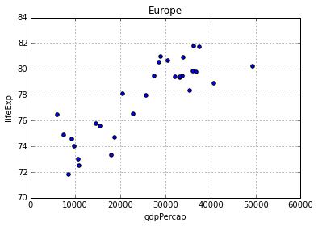

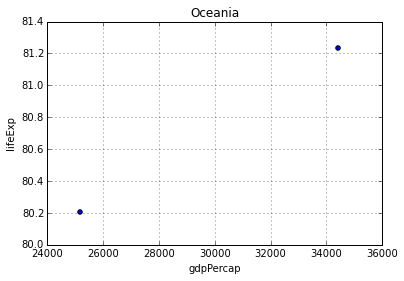

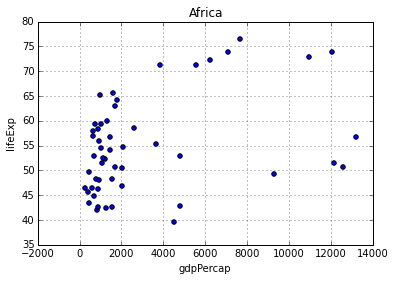

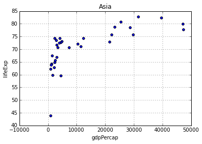

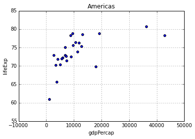

```python
c=gDat.groupby(['continent'])
for cont in c.groups:
    group=c.get_group(cont)
    group[group['year']==2007].plot(kind='scatter',x='gdpPercap',y='lifeExp',title=cont)
    #plt.axis([-10000,60000,30,90]) #add this in
```

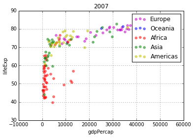

```python
fig,ax=plt.subplots(1,1)
cols=['m','b','r','g','y']
for cont, col in zip(c.groups,cols):
    group=c.get_group(cont)
    group[group['year']==2007].plot(kind='scatter',x='gdpPercap',y='lifeExp',label=cont,ax=ax,color=col,alpha=0.5)
ax.set_title(2007)
```

### Exercise

Write a function the takes a country as an argument and plots the life expectancy against GDP per capita for all years in a scatter plot. Also print the year of the minimum/maximum lifeExp and the year of the miniimim/maximum GDP per capita.

```python
def compare_gdp_lifeExp(gDat,country):
    """ plot GDP per capita against life expectancy for a given country.
    print year of min/max gdp per capita and life expectancy
    """

    sub=gDat[gDat['country']==country]
    sub.plot(x='gdpPercap',y='lifeExp',kind='scatter',title=country)

    print 'Year of Min/Max GDP per capita'
    print gDat.ix[[sub['gdpPercap'].idxmin(),sub['gdpPercap'].idxmax()]]['year']
    print 'Year of Min/Max life expectancy'
    print gDat.ix[[sub['lifeExp'].idxmin(),sub['lifeExp'].idxmax()]]['year']
```

```
Year of Min/Max GDP per capita
9    1997
6    1982
Name: year, dtype: int64
Year of Min/Max life expectancy
0     1952
11    2007
Name: year, dtype: int64
```

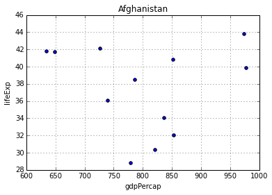

```python
compare_gdp_lifeExp(gDat,'Afghanistan')
```

```
Year of Min/Max GDP per capita
240    1952
251    2007
Name: year, dtype: int64
Year of Min/Max life expectancy
240    1952
251    2007
Name: year, dtype: int64
```

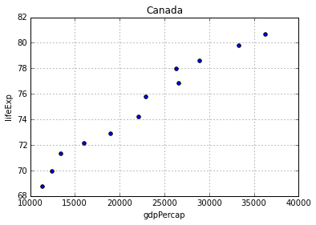

```python
compare_gdp_lifeExp(gDat,'Canada')
```

Other resources for plotting: * http://pandas.pydata.org/pandas-docs/stable/visualization.html#trellis-plotting-interface

## Summary

- pandas is a powerful tool for reading and manipulating tabular data
- subsets of data can be created using == and isin()
- data can be grouped by similar values using groupby
- pivot tables can be used to calculate aggregate statistics over certain variables
- pandas supports some simple plotting features